## Xu and Tenenbaum 2007b Replication

### Supplementary Information

**TABLE OF CONTENTS**  
**(1) Xu and Tenenabum 2007b (original)**  
**(2) Exp. 1 - online**  
**(3) Exp. 2 - online**  
**(4) Exp. 3 - in person**  
**(5) Exp. 4 - online**  
**(5) All**

This document was created from an R Markdown file. The R Markdown file can be found [here](https://github.com/mllewis/RC/blob/master/analysis/refComplex_paper_analyses_LF.Rmd). All analyses and plots can be reproduced from the [raw data](https://github.com/mllewis/RC/tree/master/data) with the code in this file. This document also contains links to the experimental tasks.

There are different possible criteria for categorizing a participant as a subordinate or basic-level generalizer. X&T find that participants respond consistently across questions as either a subordinate or a basic generalizer for each of the two trials. In contrast, we observed a wide variety of responses across questions by participants in our sample. Thus, we adopt two criteria in analyzing our data: a “strict” criteria where we only include participants if they responded consistently (“yes” or “no” to all basic-level questions and “yes” or “no” to all subordinate level questions), and a ``liberal" criteria where we counted a particpant as a basic generalizer if they responded “yes” to any of the basic level questions. The results of the liberal criteria are described in the Main Text, and the results of the strict criteria are described in Appendix A.

```
## [1] "Strict criteria:  FALSE"
```

### Original Xu and Tenenbaum 2007b

X&T 2007b data - adults

```r
N = 14
N_per_condition = (N/2) #* 2 #2 conditions and 2 trials per participant per condition
# Note: The proportions described in the original report were obtained by aggegating across *trials* not participants. We correct for this here by taking the proportion of participants, which results in slightly different proportions than those reported in the original report.

prop_sub_teacher= .928
n_sub_teacher = round(prop_sub_teacher * N_per_condition)
n_basic_teacher = N_per_condition - n_sub_teacher
teacher_xt_data = as.factor(c(rep("sub", n_sub_teacher),
                              rep("basic", n_basic_teacher)))

prop_sub_learner = .357
n_sub_learner = round(prop_sub_learner * N_per_condition)
n_basic_learner= N_per_condition - n_sub_learner
learner_xt_data = as.factor(c(rep("sub", n_sub_learner),
                              rep("basic", n_basic_learner)))

xt_data.adults = data.frame(response=c(as.character(teacher_xt_data),
                                       as.character(learner_xt_data)))
xt_data.adults$Answer.sample[1:N_per_condition] = "teacher"
xt_data.adults$Answer.sample[(N_per_condition+1):
                              (N_per_condition*2)] = "learner"

# get proportions and bootstrapped CIS
M <- data.frame()
for (k in 1:length(levels(learner_xt_data))){
    M = rbind(M, ddply(xt_data.adults, .(Answer.sample),
                     function (d) {get.prop.CIs(d$response, levels(d$response)[k])}))
}

xt.a.props = M
names(xt.a.props)[names(xt.a.props) == "ps.boot"] = "prop"
xt.a.props$exp ="X&T (2007b)"

# add n's
xt.a.props[xt.a.props$Answer.sample == "teacher" &
           xt.a.props$w.ans.cat == "sub", "n" ] = n_sub_teacher
xt.a.props[xt.a.props$Answer.sample == "teacher" &
           xt.a.props$w.ans.cat == "basic", "n"] = n_basic_teacher
xt.a.props[xt.a.props$Answer.sample == "learner" &
           xt.a.props$w.ans.cat == "sub", "n" ] = n_sub_learner
xt.a.props[xt.a.props$Answer.sample == "learner" &
           xt.a.props$w.ans.cat == "basic", "n" ] = n_basic_learner
```

X&T 2007b data - children

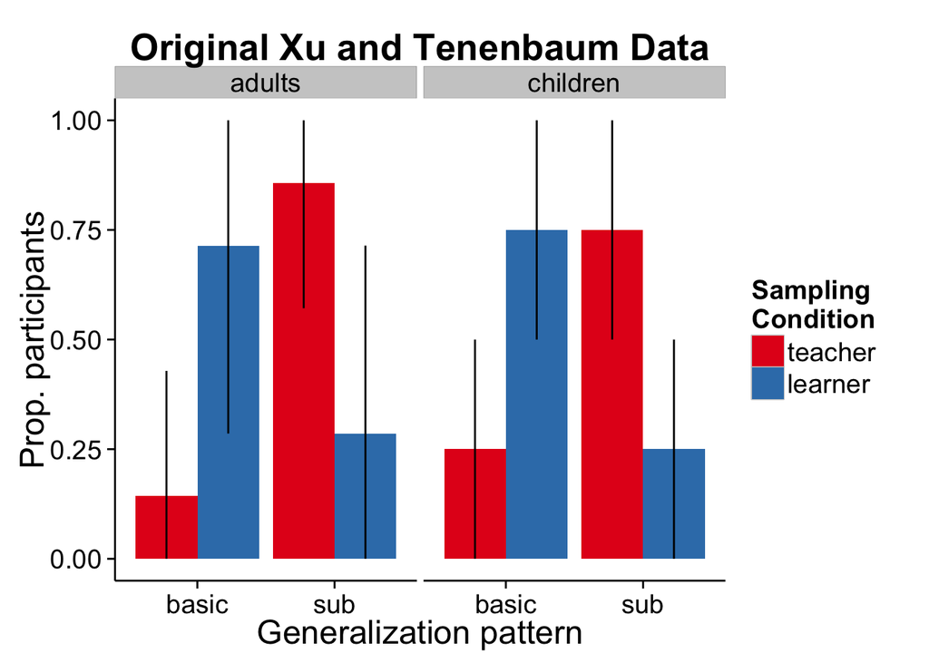

```r
N = 24
N_per_condition = (N/2) #* 2 # 12/condition, 2 trials per participant

prop_sub_teacher= .71
n_sub_teacher = round(prop_sub_teacher * N_per_condition)
n_basic_teacher = N_per_condition - n_sub_teacher
teacher_xt_data = as.factor(c(rep("sub", n_sub_teacher),
                              rep("basic", n_basic_teacher)))

prop_sub_learner = .29
n_sub_learner = round(prop_sub_learner * N_per_condition)
n_basic_learner= N_per_condition - n_sub_learner
learner_xt_data = as.factor(c(rep("sub", n_sub_learner),
                              rep("basic", n_basic_learner)))

xt_data.children = data.frame(response=c(as.character(teacher_xt_data),
                                       as.character(learner_xt_data)))
xt_data.children$Answer.sample[1:N_per_condition] = "teacher"
xt_data.children$Answer.sample[(N_per_condition+1):
                               (2*N_per_condition)] = "learner"

# get proportions and bootstrapped CIS
M <- data.frame()
for (k in 1:length(levels(learner_xt_data))){
    M = rbind(M, ddply(xt_data.children, .(Answer.sample),
                     function (d) {get.prop.CIs(d$response, levels(d$response)[k])}))
}

xt.c.props = M
names(xt.c.props)[names(xt.c.props) == "ps.boot"] = "prop"
xt.c.props$exp ="X&T (2007b) children"

# add n's
xt.c.props[xt.c.props$Answer.sample == "teacher" &
           xt.c.props$w.ans.cat== "sub", "n" ] = n_sub_teacher
xt.c.props[xt.c.props$Answer.sample == "teacher" &
           xt.c.props$w.ans.cat== "basic", "n"] = n_basic_teacher
xt.c.props[xt.c.props$Answer.sample == "learner" &
           xt.c.props$w.ans.cat== "sub", "n" ] = n_sub_learner
xt.c.props[xt.c.props$Answer.sample == "learner" &
           xt.c.props$w.ans.cat== "basic", "n" ] = n_basic_learner
```

### Experiment 1

Read in data and pre-process.

```r
t1 = read.csv("../data/turk_replication_1.csv")

# make factors
t1$Answer.sample <- factor(t1$Answer.sample, labels=c('teacher','learner')) # sample0= teacher, sample1=learner
t1$Answer.label <- factor(t1$Answer.label, labels=c('nolabel','label')) # 0=nolabel, 1=label

t1 <- colwise(as.factor)(t1)
```

Filter.

```r
# get number of exclusions by category
t1.exclusion.ns = t1 %>%
              summarise(n_noLabelParticipants = length(which(Answer.label != 'label')),
                        n_repeatWorkers = length(which(duplicated(workerid))),
                        n_badTraining = length(which(Answer.click1 == "\"false\"" |
                                                       Answer.click2 == "\"false\"")),
                        n_badGeneralize = length(which(Answer.Qwcheck != 0)),
                        n_badFilter = length(which(Answer.question1 == 'FALSE')))

t1.exclusion.ns
```

```
##   n_noLabelParticipants n_repeatWorkers n_badTraining n_badGeneralize
## 1                    48               8            21               8
##   n_badFilter
## 1           0
```

```r
# subset data
t1.f = t1 %>%
       filter(Answer.label == 'label') %>% #remove nolabel participants (run 4)
       filter(!duplicated(workerid)) %>% #participants who completed multiple runs
       filter(Answer.click1 == "\"correct\"" &
                Answer.click2 == "\"correct\"") %>% #correct training items (learning only)
       filter(Answer.Qwcheck == 0)  %>% #check generalization question
       filter(Answer.question1 == 'TRUE') #filter question

dim(t1)[1] # total
```

```
## [1] 350
```

```r
dim(t1)[1] - t1.exclusion.ns[1,"n_noLabelParticipants"] - t1.exclusion.ns[1,"n_repeatWorkers"] # actual total
```

```
## [1] 294
```

```r
dim(t1.f)[1] # total with exclusions
```

```
## [1] 274
```

Categorize response patterns based on criterion.

```r
sub <- t1.f$Answer.Qwsmm1 == 0 & t1.f$Answer.Qwsmm2 == 0 &
  t1.f$Answer.Qwsm1 == 1 & t1.f$Answer.Qwsm2 == 1
if (strict){
  basic <- (t1.f$Answer.Qwsmm1 == 1 & t1.f$Answer.Qwsmm2 == 1) &
      t1.f$Answer.Qwsm1 == 1 & t1.f$Answer.Qwsm2 == 1
} else {
  basic <- (t1.f$Answer.Qwsmm1 == 1 | t1.f$Answer.Qwsmm2 == 1) &
       t1.f$Answer.Qwsm1 == 1 & t1.f$Answer.Qwsm2 == 1
}

t1.f$w.ans.cat <- "other"
t1.f$w.ans.cat[sub] <- "sub"
t1.f$w.ans.cat[basic] <- "basic"

if (proper){
  #proper <- t1.f$Answer.Qwsmm1 == 0 & t1.f$Answer.Qwsmm2 == 0 &
  #      (t1.f$Answer.Qwsm1 == 0 & t1.f$Answer.Qwsm2 == 0)
  proper <- t1.f$Answer.Qwsmm1 == 0 & t1.f$Answer.Qwsmm2 == 0 &
        (t1.f$Answer.Qwsm1 == 0 | t1.f$Answer.Qwsm2 == 0)
  t1.f$w.ans.cat[proper] <- "proper"
  t1.f$w.ans.cat = factor(t1.f$w.ans.cat, levels=c("proper", "sub", "basic", "other"))
} else {
  t1.f$w.ans.cat = factor(t1.f$w.ans.cat, levels=c("sub", "basic", "other"))
}

# filter out other responses
length(which(t1.f$w.ans.cat == "other"))
```

```
## [1] 79
```

```r
t1.f = t1.f[t1.f$w.ans.cat != "other",]
t1.f$w.ans.cat = droplevels(t1.f$w.ans.cat)

# get proportions and bootstrapped CIS
M <- data.frame()
for (k in 1:length(levels(t1.f$w.ans.cat))){
    M = rbind(M, ddply(t1.f, .(Answer.sample),
                     function (d) {get.prop.CIs(d$w.ans.cat, levels(d$w.ans.cat)[k])}))
}

t1.f.props = t1.f %>%
          group_by(Answer.sample, w.ans.cat) %>%
          summarise (n = n()) %>%
          mutate(prop = n / sum(n),
                 exp = "Turk #1") %>%
          left_join(M)
```

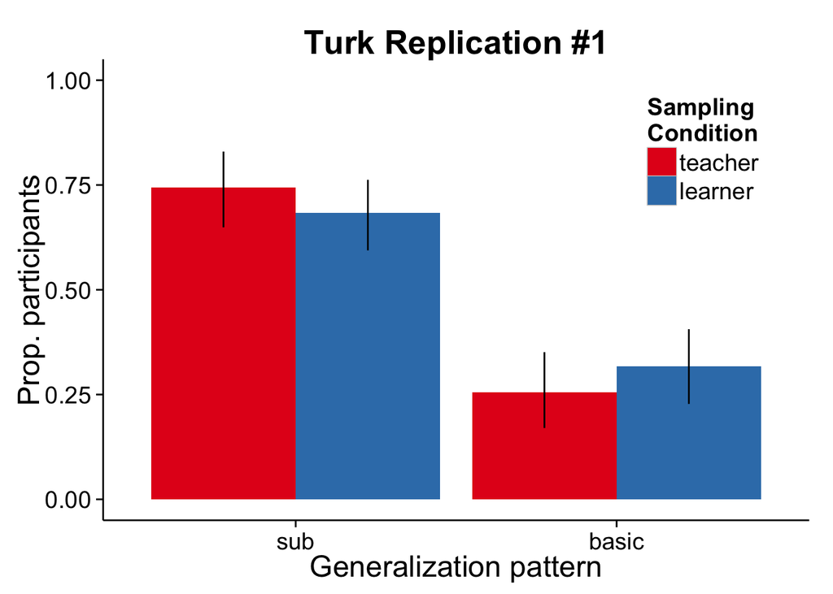

Stats

```r
t1_tab = table(t1.f$w.ans.cat, t1.f$Answer.sample)[c("sub", "basic"),]
chisq.test(t1_tab)
```

```
##
##  Pearson's Chi-squared test with Yates' continuity correction
##
## data:  t1_tab
## X-squared = 0.62452, df = 1, p-value = 0.4294
```

### Experiment 2

Read in data and pre-process

```r
t2 <- read.csv("../data/turk_replication_2.csv", sep="\t", header=T)
t2  <- t2 [,c(-1:-19,-21:-32,-36,-41:-43,-54:-55,-56)] # remove unnecessary columns

# make factors
t2$Answer.sample <- factor(t2$Answer.sample, labels=c('teacher','learner')) # sample0 = teacher, sample1=learner
t2 <- colwise(as.factor)(t2)
```

Filter.

```r
# get number of exclusions by category
t2.exclusion.ns = t2 %>%
              summarise(n_badTraining = length(which(Answer.click1 != "\"correct\"" |
                                                       Answer.click2 != "\"correct\"")),
                        n_badGeneralize = length(which(Answer.Qcheck1 != 0 | Answer.Qcheck2 != 0)),
                        n_badFilter = length(which(Answer.question1 != 'true' |
                                                     Answer.question2 != 'true' |
                                                     Answer.question3 != 'true' | Answer.question4 !='true')))
t2.exclusion.ns
```

```
##   n_badTraining n_badGeneralize n_badFilter
## 1            22              15           9
```

```r
# subset data
t2.f = t2 %>%
       filter(Answer.click1 == "\"correct\"" &
                Answer.click2 == "\"correct\"") %>% # take out those who click on wrong training items
      filter(Answer.Qcheck1 == 0 & Answer.Qcheck2 == 0) %>% # take out if missed check generalization question
      filter(Answer.question1 != 'true' | Answer.question2 != 'true' | Answer.question3 == 'true' & Answer.question4 =='true')  # take out those who missed attention check questions

dim(t2)[1] # total
```

```
## [1] 150
```

```r
dim(t2.f)[1] # total with exclusions
```

```
## [1] 118
```

Categorize response patterns based on criterion.

```r
sub <-  t2.f$Answer.Qproper1 == 1 & t2.f$Answer.Qproper2 == 1 &
  t2.f$Answer.Qproper3 == 1 & t2.f$Answer.Qsub1 == 1 &
  t2.f$Answer.Qsub2 == 1 & t2.f$Answer.Qbasic1 == 0 &
  t2.f$Answer.Qbasic2 == 0 & t2.f$Answer.Qbasic3 == 0

if (strict){
  basic <- t2.f$Answer.Qproper1 == 1 & t2.f$Answer.Qproper2 == 1 &
    t2.f$Answer.Qproper3 == 1 & t2.f$Answer.Qsub1 == 1 &
    t2.f$Answer.Qsub2 == 1 & t2.f$Answer.Qbasic1 == 1 &
    t2.f$Answer.Qbasic2 == 1 & t2.f$Answer.Qbasic3 == 1
} else {
  basic <- t2.f$Answer.Qproper1 == 1 & t2.f$Answer.Qproper2 == 1 &
    t2.f$Answer.Qproper3 == 1 & t2.f$Answer.Qsub1 == 1 &
    t2.f$Answer.Qsub2 == 1 & (t2.f$Answer.Qbasic1 == 1 |
    t2.f$Answer.Qbasic2 == 1 | t2.f$Answer.Qbasic3 == 1)
}

t2.f$w.ans.cat <- "other"
t2.f$w.ans.cat[sub] <- "sub"
t2.f$w.ans.cat[basic] <- "basic"

if(proper){
  proper <- (t2.f$Answer.Qproper1 == 1 & t2.f$Answer.Qproper2 == 1 &
    t2.f$Answer.Qproper3 == 1) & t2.f$Answer.Qsub1 == 0 &
    t2.f$Answer.Qsub2 == 0 & t2.f$Answer.Qbasic1 == 0 &
    t2.f$Answer.Qbasic2 == 0 & t2.f$Answer.Qbasic3 == 0

    t2.f$w.ans.cat[proper] <- "proper"
    t2.f$w.ans.cat = factor(t2.f$w.ans.cat, levels=c("proper", "sub", "basic", "other"))

} else {
  t2.f$w.ans.cat = factor(t2.f$w.ans.cat, levels=c("sub", "basic", "other"))
}

# filter out "other" responses
length(which(t2.f$w.ans.cat == "other"))
```

```
## [1] 28
```

```r
t2.f = t2.f[t2.f$w.ans.cat != "other",]
t2.f$w.ans.cat = droplevels(t2.f$w.ans.cat)

# get proportions and bootstrapped CIS
M <- data.frame()
for (k in 1:length(levels(t2.f$w.ans.cat))){
    M = rbind(M, ddply(t2.f, .(Answer.sample),
                     function (d) {get.prop.CIs(d$w.ans.cat, levels(d$w.ans.cat)[k])}))
}

t2.f.props = t2.f %>%
          group_by(Answer.sample, w.ans.cat) %>%
          summarise (n = n()) %>%
          mutate(prop = n / sum(n),
                 exp = "Turk #2") %>%
          left_join(M)
```

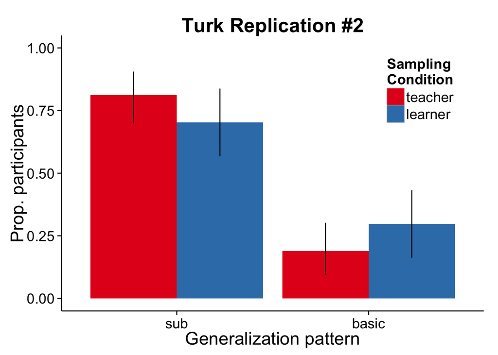

Stats

```r
t2_tab = table(t2.f$w.ans.cat, t2.f$Answer.sample)[c("sub", "basic"),]
chisq.test(t2_tab)
```

```
##
##  Pearson's Chi-squared test with Yates' continuity correction
##
## data:  t2_tab
## X-squared = 0.89395, df = 1, p-value = 0.3444
```

### Experiment 3 - In Lab Replication

```r
l1 <- read.csv("../data/inlab_replication.csv")

# make factors
l1 <- colwise(as.factor)(l1)
names(l1)[names(l1) == "sample"] = "Answer.sample"
```

Filter.

```r
l1.exclusion.ns = l1 %>%
                  summarise(n_badTraining = length(which(t2_a == 0 | t3_a == 0 |
                                                           t2_b == 0 | t2_b == 0)))
l1.exclusion.ns
```

```
##   n_badTraining
## 1             1
```

```r
# subset data
l1.f = l1 %>%
       filter(t2_a == 1 & t3_a == 1 & t2_b == 1 & t2_b == 1)

dim(l1)[1] # total
```

```
## [1] 41
```

```r
dim(l1.f)[1] # total with exclusions
```

```
## [1] 40
```

Categorize response patterns based on criterion.

```r
sub <- l1.f$basic1_a == 0 & l1.f$basic2_a == 0 &
       l1.f$basic1_b == 0 & l1.f$basic2_b == 0 &
       (l1.f$sub1_a == 1 & l1.f$sub2_a == 1 &
          l1.f$sub1_b == 1 & l1.f$sub2_b == 1)
if (strict){
    basic <- (l1.f$basic1_a == 1 & l1.f$basic2_a == 1 &
            l1.f$basic1_b == 1 & l1.f$basic2_b == 1) &
           (l1.f$sub1_a == 1 & l1.f$sub2_a == 1 &
              l1.f$sub1_b == 1 & l1.f$sub2_b == 1)

} else {
  basic <- (l1.f$basic1_a == 1 | l1.f$basic2_a == 1 |
            l1.f$basic1_b == 1 | l1.f$basic2_b == 1) &
           (l1.f$sub1_a == 1 & l1.f$sub2_a == 1 &
              l1.f$sub1_b == 1 & l1.f$sub2_b == 1)
}

l1.f$w.ans.cat <- "other"
l1.f$w.ans.cat[sub] <- "sub"
l1.f$w.ans.cat[basic] <- "basic"

if (proper){
  proper <- l1.f$basic1_a == 0 & l1.f$basic2_a == 0 &
            l1.f$basic1_b == 0 & l1.f$basic2_b == 0 &
            (l1.f$sub1_a == 0 | l1.f$sub2_a == 0 |
               l1.f$sub1_b == 0 | l1.f$sub2_b == 0)
  l1.f$w.ans.cat[proper] <- "proper"
  l1.f$w.ans.cat <- factor(l1.f$w.ans.cat,c("proper","sub","basic","other"))
} else {
  l1.f$w.ans.cat <- factor(l1.f$w.ans.cat,c("sub","basic","other"))
}

# filter out "other"" responses
length(which(l1.f$w.ans.cat  == "other"))
```

```
## [1] 9
```

```r
l1.f = l1.f[l1.f$w.ans.cat != "other",]
l1.f$w.ans.cat = droplevels(l1.f$w.ans.cat)

# get proportions and bootstrapped CIS
M <- data.frame()
for (k in 1:length(levels(l1.f$w.ans.cat))){
    M = rbind(M, ddply(l1.f, .(Answer.sample),
                     function (d) {get.prop.CIs(d$w.ans.cat, levels(d$w.ans.cat)[k])}))
}

l1.f.props = l1.f %>%
          group_by(Answer.sample, w.ans.cat) %>%
          summarise (n = n()) %>%
          mutate(prop = n / sum(n),
                 exp = "In Lab") %>%
          left_join(M)

# re-order levels so consistent with other exps
l1.f.props$Answer.sample <- ordered(l1.f.props$Answer.sample,
                    levels = c("teacher", "learner"))
```

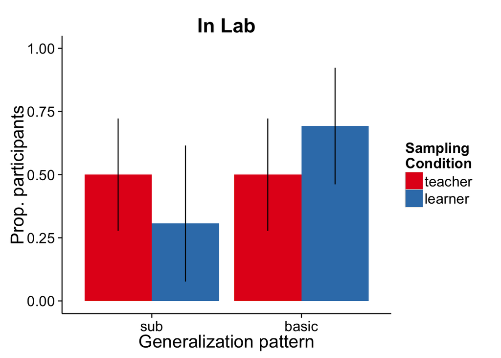

Stats

```r
l1_tab = table(l1.f$w.ans.cat, l1.f$sample)[c("sub", "basic"),]
chisq.test(l1_tab)
```

```
##
##  Pearson's Chi-squared test with Yates' continuity correction
##
## data:  l1_tab
## X-squared = 0.49269, df = 1, p-value = 0.4827
```

### Experiment 4 - Turk Replication #3

Read in data and pre-process

```r
t3 <- read.csv("../data/turk_replication_3.csv")

# make factors
t3$Answer.sample <- factor(t3$Answer.sample, labels=c('teacher','learner')) # sample0 = teacher, sample1=learner
t3 <- colwise(as.factor)(t3)
```

Filter.

```r
t3.exclusion.ns = t3 %>%
              summarise(n_badTraining = length(which(Answer.click1 != "\"correct\"" |
                                                       Answer.click2 != "\"correct\"")),
                        n_badGeneralize = length(which(Answer.Qcheck1 != 0 | Answer.Qcheck2 != 0)),
                        n_badFilter = length(which(Answer.question1 != 'TRUE' | Answer.question2 !='TRUE'|
                                Answer.question3 != 'TRUE' | Answer.question4 !='TRUE')))
t3.exclusion.ns
```

```
##   n_badTraining n_badGeneralize n_badFilter
## 1            27              17          10
```

```r
# subset data
t3.f= t3 %>%
      filter(Answer.click1 == "\"correct\"" &
                Answer.click2 == "\"correct\"") %>% # take out those who click on wrong training items
      filter(Answer.Qcheck1 == 0 & Answer.Qcheck2 == 0) %>% # take out if missed check generalization question
      filter(Answer.question1 == 'TRUE' & Answer.question2 =='TRUE' &
            Answer.question3 == 'TRUE' & Answer.question4 =='TRUE')  # take out those who missed filter question

dim(t3)[1] # total
```

```
## [1] 200
```

```r
dim(t3.f)[1] # total with exclusions
```

```
## [1] 161
```

Categorize response patterns based on criterion.

```r
sub <-  t3.f$Answer.Qproper1 == 1 & t3.f$Answer.Qproper2 == 1 &
    t3.f$Answer.Qproper3 == 1 & t3.f$Answer.Qsub1 == 1 &
    t3.f$Answer.Qsub2 == 1 & t3.f$Answer.Qbasic1 == 0 &
    t3.f$Answer.Qbasic2 == 0 & t3.f$Answer.Qbasic3 == 0

if (strict){
  basic <- t3.f$Answer.Qproper1 == 1 & t3.f$Answer.Qproper2 == 1 &
    t3.f$Answer.Qproper3 == 1 & t3.f$Answer.Qsub1 == 1 &
    t3.f$Answer.Qsub2 == 1 & t3.f$Answer.Qbasic1 == 1 &
    t3.f$Answer.Qbasic2 == 1 & t3.f$Answer.Qbasic3 == 1
} else {
  basic <- t3.f$Answer.Qproper1 == 1 & t3.f$Answer.Qproper2 == 1 &
      t3.f$Answer.Qproper3 == 1 & t3.f$Answer.Qsub1 == 1 &
      t3.f$Answer.Qsub2 == 1 & (t3.f$Answer.Qbasic1 == 1 |
      t3.f$Answer.Qbasic2 == 1 | t3.f$Answer.Qbasic3 == 1)
}

t3.f$w.ans.cat <- "other"
t3.f$w.ans.cat[sub] <- "sub"
t3.f$w.ans.cat[basic] <- "basic"

if (proper){
  proper <- (t3.f$Answer.Qproper1 == 1 & t3.f$Answer.Qproper2 == 1 &
            t3.f$Answer.Qproper3 == 1) & t3.f$Answer.Qsub1 == 0 &
            t3.f$Answer.Qsub2 == 0 & t3.f$Answer.Qbasic1 == 0 &
            t3.f$Answer.Qbasic2 == 0 & t3.f$Answer.Qbasic3 == 0

  t3.f$w.ans.cat[proper] <- "proper"
  t3.f$w.ans.cat = factor(t3.f$w.ans.cat, levels=c("proper", "sub", "basic", "other"))
} else {
  t3.f$w.ans.cat = factor(t3.f$w.ans.cat, levels=c("sub", "basic", "other"))
}

# filter out "other"" responses
length(which(t3.f$w.ans.cat == "other"))
```

```
## [1] 21
```

```r
t3.f = t3.f[t3.f$w.ans.cat != "other",]
t3.f$w.ans.cat = droplevels(t3.f$w.ans.cat)

# get proportions and bootstrapped CIS
M <- data.frame()
for (k in 1:length(levels(t3.f$w.ans.cat))){
    M = rbind(M, ddply(t3.f, .(Answer.sample),
                     function (d) {get.prop.CIs(d$w.ans.cat, levels(d$w.ans.cat)[k])}))
}

t3.f.props = t3.f %>%
          group_by(Answer.sample, w.ans.cat) %>%
          summarise (n = n()) %>%
          mutate(prop = n / sum(n),
                 exp = "Turk #3") %>%
          left_join(M)
```

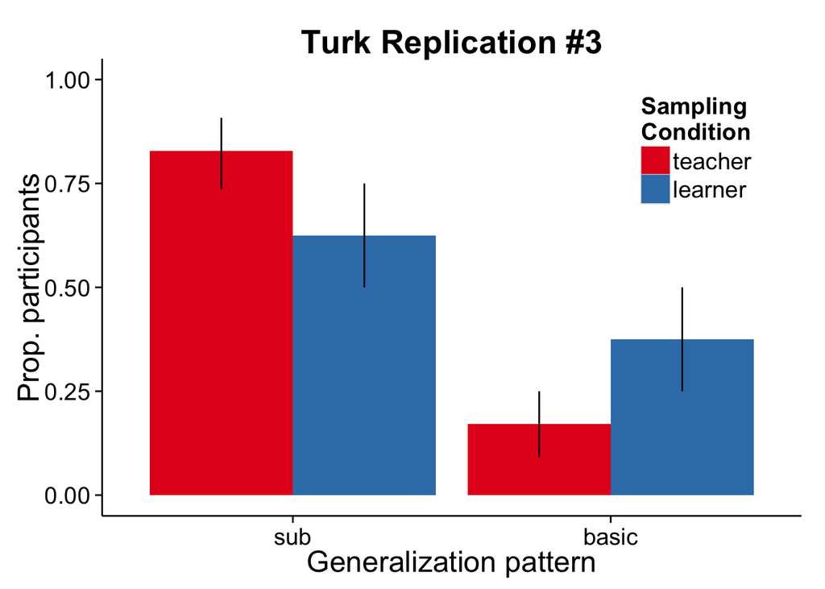

Stats

```r
t3_tab = table(t3.f$w.ans.cat, t3.f$Answer.sample)[c("sub", "basic"),]
chisq.test(t3_tab)
```

```
##
##  Pearson's Chi-squared test with Yates' continuity correction
##
## data:  t3_tab
## X-squared = 6.4203, df = 1, p-value = 0.01128
```

### All experiments

```r
# bind all props together
lf.props = rbind(t1.f.props, t2.f.props, t3.f.props, l1.f.props)
lf.props$ps.boot <- NULL
all.props= rbind(lf.props, xt.a.props, xt.c.props)

all.props$exp <- ordered(as.factor(all.props$exp),
                    levels = c( "X&T (2007b) children", "X&T (2007b)", "Turk #1",
                                "Turk #2", "In Lab", "Turk #3"))

all.props$exp = revalue(all.props$exp, c("X&T (2007b)" = "X&T adults", "X&T (2007b) children" = "X&T children", "Turk #1" = "Exp. 1", "Turk #2" = "Exp. 2", "In Lab" = "Exp. 3", "Turk #3" = "Exp. 4"))
all.props$w.ans.cat  = revalue(all.props$w.ans.cat , c("sub" = "sub."))

all.props.crit = all.props[all.props$w.ans.cat == "basic" | all.props$w.ans.cat == "sub.",]
```

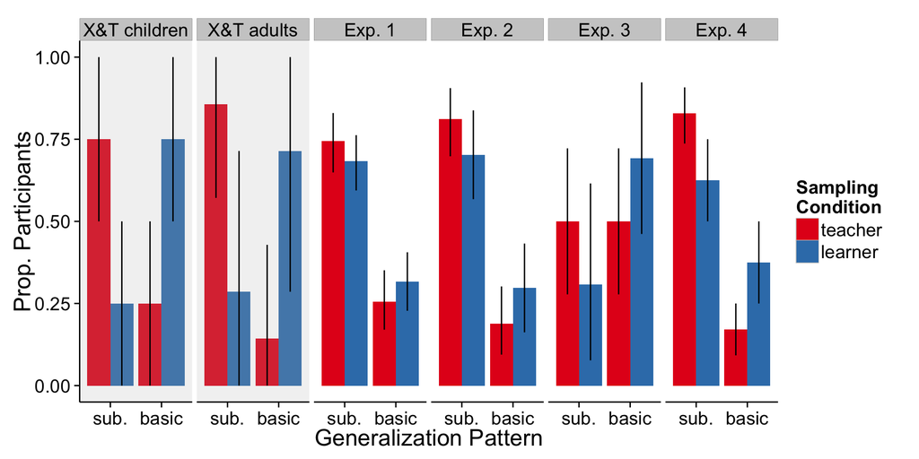

Effect sizes

```r
t1.f.es = d.fc(t1.f$w.ans.cat, t1.f$Answer.sample)
t2.f.es= d.fc(t2.f$w.ans.cat, t2.f$Answer.sample)
t3.f.es = d.fc(t3.f$w.ans.cat, t3.f$Answer.sample)
l1.f.es= d.fc(l1.f$w.ans.cat, l1.f$Answer.sample)
xt.a.es = d.fc(xt_data.adults$response, xt_data.adults$Answer.sample)
xt.c.es = d.fc(xt_data.children$response, xt_data.children$Answer.sample)

all.es = rbind(t1.f.es, t2.f.es, t3.f.es, l1.f.es, xt.a.es, xt.c.es)
all.es$exp = c("Turk #1" ,"Turk #2", "Turk #3", "In Lab",
               "X&T adults", "X&T children")
all.es$exp<- ordered(as.factor(all.es$exp),
                     levels = c( "X&T children", "X&T adults", "Turk #1" ,"Turk #2",
                                  "In Lab", "Turk #3"))
all.es$exp = revalue(all.es$exp, c( "Turk #1" = "Exp. 1",
                                "Turk #2" = "Exp. 2", "In Lab" = "Exp. 3",
                                "Turk #3" = "Exp. 4"))
all.es
```

```
##   effect_size        cill      ciul          exp
## 1   0.1665404 -0.17806094 0.5111417       Exp. 1
## 2   0.3299228 -0.21321025 0.8730558       Exp. 2
## 3   0.5884663  0.15695071 1.0199818       Exp. 4
## 4   0.4470893 -0.37823616 1.2724147       Exp. 3
## 5   1.4930263  0.01663933 2.9694133   X&T adults
## 6   1.2113934  0.19258958 2.2301972 X&T children
```

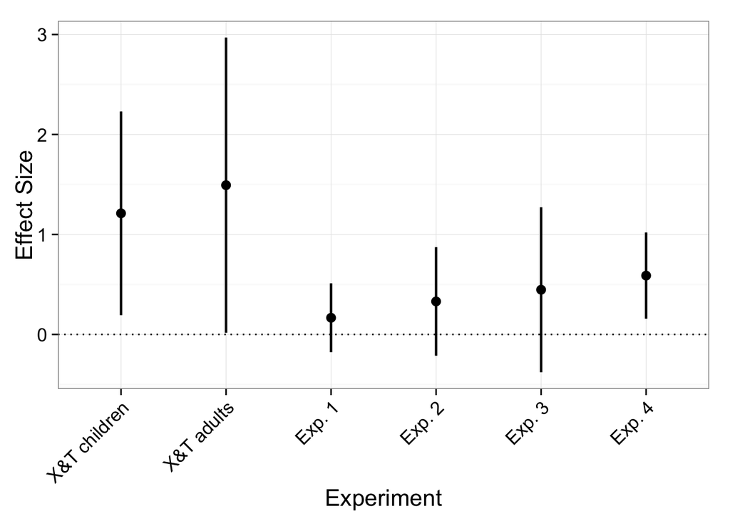